# R을 이용한 최적화 과정

### Scailing Problem

- 차량 통행과 미세먼지 농도 사이에는 정말 아무런 관계가 없을까?
- 회귀계수가 0에 가깝게 나왔기 때문에, 그렇게 볼 수도 있다.
- 농도 수치와 차량 통행량의 사이에는 단위가 굉장히 큰 것 같지 않나요?
- 미세먼지 농도와 차량 통행량으 단위가 다르기 때문에 회귀계수가 작은 것처럼 보이게 된다.
  - 실제로 미세먼지 종도가 50정도라면 굉장히 높은 수치인데
  - 차량 통행량에 비하면 아주 낮은 수치가 된다.
- 자료의 평균을 빼주고(Centering) 표준편차로 나눠주는 (scaling)과정을 통해 문제를 해결할 수 있다.
- R의 scale()함수를 이용할 수 있다.

```r
lm_scaled_result
```

```
Call:
lm(formula = scaledY ~ scaledX)

Coefficients:
(Intercept)      scaledX
  7.507e-17    1.866e-01
```

### 회귀계수란?

- 찾으려는 모수 정도로만 얘기를 했었다.
- 회귀계수가 가지는 의미는
  - 입력변수x가 반응변수y에 미치는 영향 정도로 생각을 해볼 수 있다.
  - 즉, 입력변수 x가 1 증가할 때 마다, 회귀계수만큼 영향이 증가한다고 볼 수 있다.
  - 만일, 회귀계수가 음수라면 입력변수 x가 1증가할 때마다 회귀계수만큼 영향이 감소한다고 볼 수 있다.
- 전체 데이터에서 회귀모형에 적합한 결과를 보면
  - ncar 변수의 회귀 계수가 ncar하나만 가지고 회귀모형을 적합했을 때와 전체를 가지고 적합을 한 경우
  - 회귀 계수가 다르게 계산됨을 확인했다.
  - 다변수 회귀분석을 진행하는 경우 각 변수들은 반드시 독립적이어야 한다.
  - 독립적이라면 변수와 변수 사이의 관계가 전혀 없어야 한다. 즉 변수가 다른 변수에 영향을 끼치면 안됀다는 것을 의미 > 다변수 회귀분석인 경우 회귀분석과 회귀계수의 해석은 신중하게 진행되어야 한다. > 어차피 우리가 확인하는 값들은 전부 수치적으로 계산된 값일 뿐 > 실제 의미를 전혀 반영하지 못한다(거짓말, 새빨간 거짓말, 그리고 통계)

# 선형회귀모형의 특징

- 파이썬을 통한 선형회귀 수업에서도 다시 한 번 다룰 겁니다.
- 선형회귀모형과 같은 경우 해석이 아주 쉽고, 심지어 최적의 모수를 직접 계산할 수도 있다.
- 그리고 직관적으로 그 구조를 파악하기가 쉽다는 장점이 있다.
- 때문에 널리 사용이 된다.
- 많은 통계적 모형들이 선형회귀모형을 응용한 형태로 사용을 한다.
  - 예를 들면 딥러닝 같은 경우 선형회귀모형에 활성함수를 씌운 것을 겹겹이 쌓아올려서 동작하는 구조
  - 그래서, 딥러닝을 그냥 선형회귀라고 부르는 사람들도 있다.
  - 다만, 모수를 많이 늘려서 정확도를 높이는 방법이 딥러닝이다.
- 선형회귀모형은 통계적 모형 에서도 가장 기본적이면서 가장 중요한 모형이라고 볼 수 있다.

# 실습

1. 탐색적 자료 분석을 통해서 CO, NO2, ncar 변수와 관계를 확인해보자.
2. 단순선형회귀 모형을 이용해 CO 변수와 ncar변수 사이의 관계를 확인해보자.
3. 선형회귀모형을 통해 CO와 NO2, ncar 변수 사이의 관계를 확인해보자.
4. 차량통행량이 80000, NO2 농도가 0.03 정도라면 CO농도는 어느 정도로 예측될 수 있는지 확인해보자.

# 실습문제 풀이

1. 탐색적 자료분석을 통해 CO, NO2, ncar 변수들의 관계를 확인해보자

```r
pmcarkw %>%
  select(CO, NO2, ncar) %>%
cor()
```

```
            CO       NO2      ncar
CO   1.0000000 0.7366613 0.2099273
NO2  0.7366613 1.0000000 0.2782408
ncar 0.2099273 0.2782408 1.0000000
```

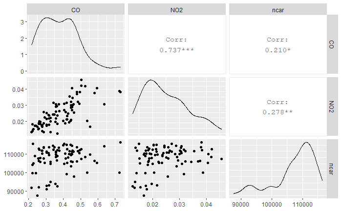

2. 단순선형회귀모형을 이용해 CO 변수와 ncar 변수 사이의 관계를 확인해보자

```r
result
```

```
Call:
lm(formula = CO ~ ncar, data = pmcarkwScaled)

Coefficients:
(Intercept)         ncar
 -1.286e-16    2.099e-01
```

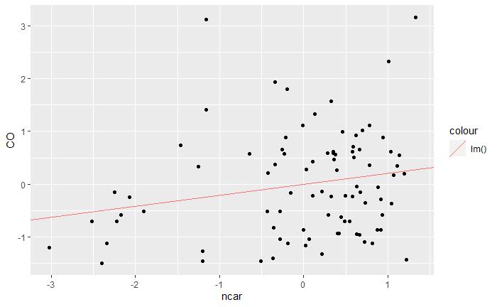

3. 선형회귀모형을 통해 CO, NO2, ncar 변수사이의 관계를 확인해보자.

```r
result2
```

```
Call:
lm(formula = CO ~ ncar + NO2, data = pmcarkwScaled)

Coefficients:
(Intercept)         ncar          NO2
 -9.776e-17    5.374e-03    7.352e-01
```